# Prévision horaire de la charge électrique en France

La prévision de la charge électrique est un enjeu central pour l’équilibre du système électrique, en particulier à court terme. La consommation présente de fortes dépendances temporelles ainsi que des variations liées aux conditions météorologiques, notamment à la température.

L’objectif de ce projet est de construire et comparer plusieurs modèles de prévision horaire de la charge électrique en France, à partir de données historiques de consommation et de température, sur la période 2020–2023.

Les données utilisées sont :

- la consommation électrique horaire en France (source : RTE / ODRÉ),
- la température horaire issue des observations météorologiques (Météo-France, Archive SYNOP OMM).

La démarche suivie est la suivante :

1. Analyse exploratoire des données (EDA) afin d’identifier les principales structures temporelles.
2. Mise en place d’un modèle de référence (persistance).
3. Construction et comparaison de plusieurs modèles de prévision :
   - régression linéaire avec variables calendaires,
   - modèle SARIMAX avec température exogène,
   - modèle de séries temporelles ETS (Holt-Winters).
4. Comparaison des performances à l’aide des métriques MAE et RMSE.

## 1. Collecte et préparation des données

### Objectif de la section

Cette section vise à construire un jeu de données horaire, propre et cohérent, combinant la charge électrique et la température, afin de permettre une analyse exploratoire et la mise en place de modèles de prévision à court terme.

### 1.1 Sources de données

Deux sources de données principales sont utilisées dans ce projet :

- **Consommation électrique** : données de consommation issues de la plateforme ODRÉ (RTE), fournies à une granularité infra-horaire et agrégées à l’échelle horaire.
- **Données météorologiques** : observations de température provenant de Météo-France via les archives SYNOP OMM. Les données sont relevées toutes les trois heures et interpolées afin d’obtenir une série horaire cohérente avec la consommation électrique.

Les performances des modèles sont évaluées sur une période de test indépendante (année 2023), à l’aide de l’erreur absolue moyenne (MAE) et de la racine de l’erreur quadratique moyenne (RMSE).

### 1.2 Préparation des données de consommation électrique

Les données de consommation sont chargées, nettoyées et agrégées à une fréquence horaire. La série finale est exprimée en mégawatts (MW) et indexée temporellement en heure locale (Europe/Paris).

```python
import pandas as pd

# Chargement des données de consommation électrique
path = "data/consommation_quotidienne_brute.csv.gz"
df_raw = pd.read_csv(path, sep=";")

# Sélection et renommage des colonnes utiles
df = df_raw[[
    "Date - Heure",
    "Consommation brute électricité (MW) - RTE"
]].copy()

df = df.rename(columns={
    "Date - Heure": "datetime",
    "Consommation brute électricité (MW) - RTE": "load_mw"
})

# Conversion des types
df["datetime"] = pd.to_datetime(df["datetime"], utc=True)
df["load_mw"] = pd.to_numeric(df["load_mw"], errors="coerce")

# Nettoyage et mise en forme temporelle
df = df.dropna().sort_values("datetime").set_index("datetime")

# Passage à l'horaire et conversion de fuseau
df_hourly = df.resample("h").mean()
df_hourly = df_hourly.tz_convert("Europe/Paris")

# Suppression des valeurs manquantes résiduelles
df_hourly = df_hourly.dropna()

df_hourly.head()
```

| datetime | load_mw |
| --- | --- |
| 2012-01-01 00:00:00+01:00 | 58962.0 |
| 2012-01-01 01:00:00+01:00 | 56152.5 |
| 2012-01-01 02:00:00+01:00 | 55221.0 |
| 2012-01-01 03:00:00+01:00 | 51579.5 |
| 2012-01-01 04:00:00+01:00 | 48378.0 |

### 1.3 Préparation des données météorologiques

Les données météorologiques proviennent des archives SYNOP OMM de Météo-France. Une station unique (Orly) est sélectionnée afin de disposer d’une série temporelle complète sur la période étudiée. Les températures, initialement disponibles toutes les trois heures, sont interpolées afin d’obtenir une série horaire cohérente avecc les données de consommation.

```python
# Fichiers météo SYNOP (2020–2023)
files = [
    "data/synop_2020.csv.gz",
    "data/synop_2021.csv.gz",
    "data/synop_2022.csv.gz",
    "data/synop_2023.csv.gz",
]

# Chargement et concaténation
df_meteo = pd.concat(
    [pd.read_csv(f, sep=";") for f in files],
    ignore_index=True
)

# Sélection d'une station unique (Orly)
station_name = "ORLY"
df_meteo = df_meteo[df_meteo["name"] == station_name].copy()

# Sélection des variables utiles
df_temp = df_meteo[["validity_time", "t"]].copy()

# Conversion datetime et température (Kelvin -> Celsius)
df_temp["datetime"] = pd.to_datetime(df_temp["validity_time"], utc=True)
df_temp["temperature"] = df_temp["t"] - 273.15

df_temp = (
    df_temp[["datetime", "temperature"]]
    .set_index("datetime")
    .sort_index()
    .tz_convert("Europe/Paris")
)

# Gestion des doublons temporels
df_temp = df_temp.groupby(level=0).mean()

# Passage à l'horaire (interpolation temporelle)
df_temp_hourly = df_temp.resample("h").interpolate(method="time")

df_temp_hourly.head()
```

| datetime | temperature |
| --- | --- |
| 2020-01-01 01:00:00+01:00 | -1.6 |
| 2020-01-01 02:00:00+01:00 | -1.3 |
| 2020-01-01 03:00:00+01:00 | -1.0 |
| 2020-01-01 04:00:00+01:00 | -0.7 |
| 2020-01-01 05:00:00+01:00 | -0.5 |

### 1.4 Jeu de données final

À l’issue des étapes de préparation et de nettoyage, les données de consommation électrique et de température sont fusionnées afin d’obtenir un jeu de données final à fréquence horaire.

Ce jeu de données, composé des variables `load_mw` et `temperature`, constitue la base de l’ensemble des analyses exploratoires et des modèles de prévision présentés dans la suite du projet.

```python
df_final = df_hourly.join(df_temp_hourly, how="inner")
df_final = df_final.dropna()
df_final.head()
```

| datetime | load_mw | temperature |
| --- | --- | --- |
| 2020-01-01 01:00:00+01:00 | 63729.0 | -1.6 |
| 2020-01-01 02:00:00+01:00 | 62865.0 | -1.3 |
| 2020-01-01 03:00:00+01:00 | 59883.5 | -1.0 |
| 2020-01-01 04:00:00+01:00 | 57368.0 | -0.7 |
| 2020-01-01 05:00:00+01:00 | 56370.0 | -0.5 |

## 2. Analyse exploratoire des données (EDA)

### Objectifs

L’objectif de cette étape est d’analyser la structure temporelle de la charge électrique horaire et d’identifier les principaux facteurs explicatifs, en particulier la température.

Cette analyse exploratoire permet de mettre en évidence les principales saisonnalités et de motiver les choix de modélisation effectués par la suite.

```python
df_final.info()
df_final.describe()
```

```
<class 'pandas.core.frame.DataFrame'>
DatetimeIndex: 35058 entries, 2020-01-01 01:00:00+01:00 to 2023-12-31 22:00:00+01:00
Data columns (total 2 columns):
 #   Column       Non-Null Count  Dtype
---  ------       --------------  -----
 0   load_mw      35058 non-null  float64
 1   temperature  35058 non-null  float64
dtypes: float64(2)
memory usage: 821.7 KB
```

|  | load_mw | temperature |
| --- | --- | --- |
| count | 35058.000000 | 35058.000000 |
| mean | 51301.163588 | 13.140084 |
| std | 11197.244248 | 7.186427 |
| min | 28987.000000 | -6.100000 |
| 25% | 42900.625000 | 7.933333 |
| 50% | 49439.500000 | 12.566667 |
| 75% | 58777.500000 | 18.233333 |
| max | 88426.500000 | 39.400000 |

### Statistiques descriptives

Les statistiques descriptives confirment la cohérence des données :

- la charge électrique évolue dans des ordres de grandeur réalistes (en MW),
- la température présente des valeurs compatibles avec le climat français,
- aucune valeur manquante n’est observée après le nettoyage des données.

```python
df_final["hour"] = df_final.index.hour
df_final["day_of_week"] = df_final.index.dayofweek  # 0 = lundi
df_final["month"] = df_final.index.month
df_final["is_weekend"] = df_final["day_of_week"] >= 5
```

### Profil journalier moyen

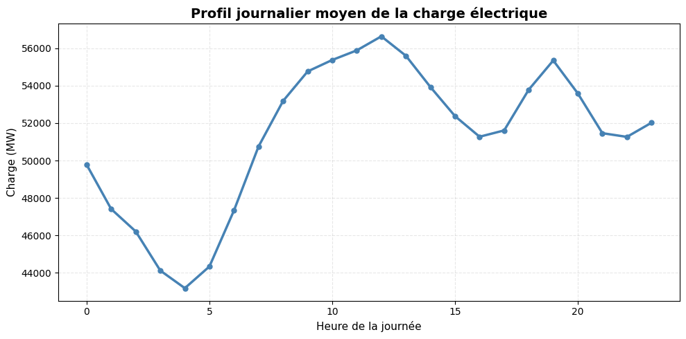

```python
import matplotlib.pyplot as plt

profile_hour = df_final.groupby("hour")["load_mw"].mean()

fig, ax = plt.subplots(figsize=(10, 5))
ax.plot(profile_hour.index, profile_hour.values,
        linewidth=2.5, color='steelblue', marker='o', markersize=5)
ax.set_title("Profil journalier moyen de la charge électrique",
             fontsize=14, fontweight='bold')
ax.set_xlabel("Heure de la journée", fontsize=11)
ax.set_ylabel("Charge (MW)", fontsize=11)
ax.grid(alpha=0.3, linestyle='--')
plt.tight_layout()
plt.show()
```

### Profil hebdomadaire

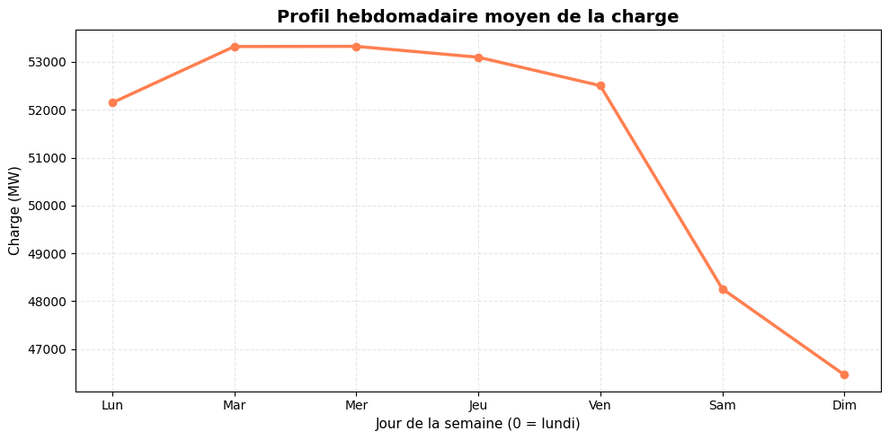

```python
profile_week = df_final.groupby("day_of_week")["load_mw"].mean()

fig, ax = plt.subplots(figsize=(10, 5))
ax.plot(profile_week.index, profile_week.values,
        linewidth=2.5, color='coral', marker='o', markersize=6)
ax.set_title("Profil hebdomadaire moyen de la charge",
             fontsize=14, fontweight='bold')
ax.set_xlabel("Jour de la semaine (0 = lundi)", fontsize=11)
ax.set_ylabel("Charge (MW)", fontsize=11)
ax.set_xticks(range(7))
ax.set_xticklabels(['Lun', 'Mar', 'Mer', 'Jeu', 'Ven', 'Sam', 'Dim'])
ax.grid(alpha=0.3, linestyle='--')
plt.tight_layout()
plt.show()
```

Le profil hebdomadaire de la charge montre un maximum le mardi, correspondant à une activité économique pleinement établie. Le minimum est observé le dimanche, en raison de la forte réduction des activités industrielles et tertiaires. Une décroissance progressive de la demande est observée à l’approche du week-end.

### Saisonnalité annuelle

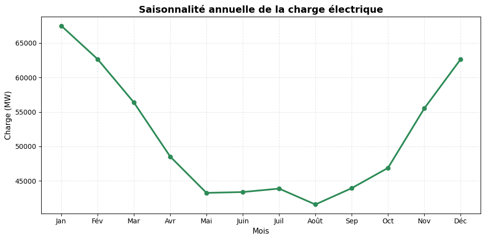

```python
profile_month = df_final.groupby("month")["load_mw"].mean()

fig, ax = plt.subplots(figsize=(10, 5))
ax.plot(profile_month.index, profile_month.values,
        linewidth=2.5, color='seagreen', marker='o', markersize=6)
ax.set_title("Saisonnalité annuelle de la charge électrique",
             fontsize=14, fontweight='bold')
ax.set_xlabel("Mois", fontsize=11)
ax.set_ylabel("Charge (MW)", fontsize=11)
ax.set_xticks(range(1, 13))
ax.set_xticklabels(['Jan', 'Fév', 'Mar', 'Avr', 'Mai', 'Juin',
                    'Juil', 'Août', 'Sep', 'Oct', 'Nov', 'Déc'])
ax.grid(alpha=0.3, linestyle='--')
plt.tight_layout()
plt.show()
```

La saisonnalité annuelle de la charge présente une forme en U. La demande est maximale en janvier et décembre, et minimale en août. Ce comportement s’explique principalement par les besoins de chauffage en hiver et la baisse d’activité durant les vacances estivales.

### Relation entre la charge et la température

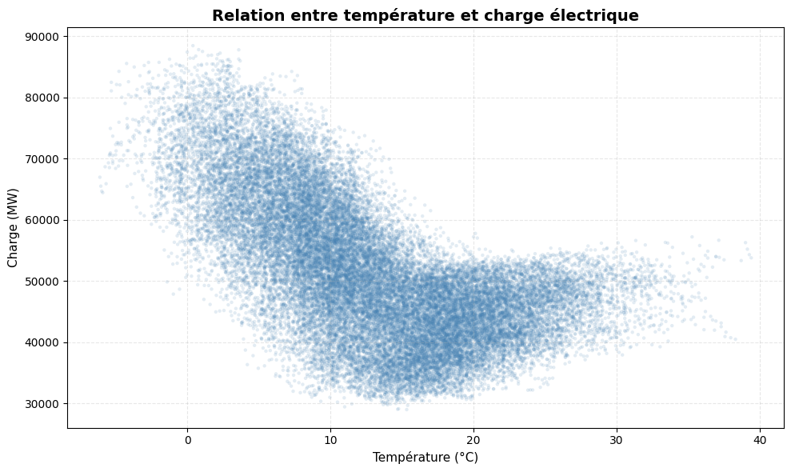

```python
fig, ax = plt.subplots(figsize=(10, 6))
ax.scatter(df_final["temperature"], df_final["load_mw"],
           alpha=0.15, s=10, color='steelblue', edgecolors='none')
ax.set_title("Relation entre température et charge électrique",
             fontsize=14, fontweight='bold')
ax.set_xlabel("Température (°C)", fontsize=11)
ax.set_ylabel("Charge (MW)", fontsize=11)
ax.grid(alpha=0.3, linestyle='--')
plt.tight_layout()
plt.show()
```

La relation entre la charge électrique et la température est clairement non linéaire. La charge augmente fortement lorsque la température est basse, en raison des besoins de chauffage. Un minimum de demande est observé pour des températures modérées (environ 15–20 °C). Aux températures élevées, la demande augmente légèrement, traduisant l’effet de la climatisation.

### Corrélation charge – température

```python
df_final[["load_mw", "temperature"]].corr()
```

|  | load_mw | temperature |
| --- | --- | --- |
| load_mw | 1.000000 | -0.622714 |
| temperature | -0.622714 | 1.000000 |

La corrélation entre la charge électrique et la température est forte et négative (environ −0.62), confirmant qu’une baisse de la température est associée à une augmentation de la demande électrique. Toutefois, la relation étant non linéaire, une simple corrélation linéaire ne suffit pas à la décrire complètement.

### Série temporelle globale

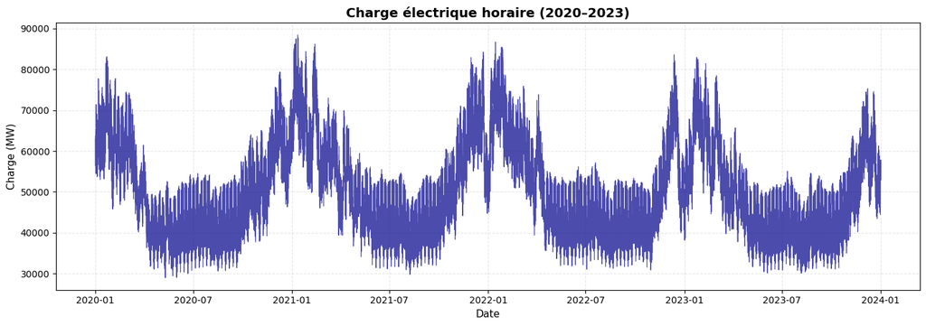

```python
fig, ax = plt.subplots(figsize=(14, 5))
ax.plot(df_final.index, df_final["load_mw"],
        linewidth=0.8, color='darkblue', alpha=0.7)
ax.set_title("Charge électrique horaire (2020–2023)",
             fontsize=14, fontweight='bold')
ax.set_xlabel("Date", fontsize=11)
ax.set_ylabel("Charge (MW)", fontsize=11)
ax.grid(alpha=0.3, linestyle='--')
plt.tight_layout()
plt.show()
```

La série temporelle de la charge électrique horaire sur la période 2020–2023 présente une forte saisonnalité annuelle, avec des pics récurrents en hiver et des creux en été. La variabilité est nettement plus importante en période hivernale, traduisant l’impact des épisodes de froid sur la demande. Aucune tendance de long terme marquée n’est observée sur la période étudiée.

### Conclusion de l’analyse exploratoire

L’analyse exploratoire met en évidence :

- des saisonnalités journalières, hebdomadaires et annuelles marquées,
- le rôle central de la température comme variable explicative de la charge électrique,
- l’absence de tendance de long terme marquée sur la période étudiée.

Ces résultats motivent l’utilisation de modèles intégrant des composantes saisonnières et, le cas échéant, des variables exogènes, présentés dans l’étape suivante.

## 3. Modélisation et prévision de la charge électrique

### Objectif

L’objectif de cette étape est de développer et comparer plusieurs modèles de prévision à court terme de la charge électrique horaire.

Les modèles sont construits progressivement, du plus simple au plus sophistiqué, afin d’évaluer l’apport des variables explicatives et des composantes saisonnières identifiées lors de l’analyse exploratoire.

### Séparation des données d’entraînement et de test

Les données sont séparées chronologiquement afin d’éviter toute fuite d’information. La période 2020–2022 est utilisée pour l’entraînement des modèles, tandis que l’année 2023 constitue le jeu de test.

```python
train = df_final[df_final.index < "2023-01-01"]
test  = df_final[df_final.index >= "2023-01-01"]

train.shape, test.shape
```

```
((26300, 6), (8758, 6))
```

### Modèle de référence : persistance

Un premier modèle de référence est basé sur le principe de persistance. La prévision de la charge à l’instant ( t+1 ) est égale à la charge observée à l’instant ( t ).

Bien que très simple, ce modèle constitue un benchmark indispensable pour la prévision à court terme. Tout modèle plus complexe doit améliorer ce résultat afin de justifier sa complexité supplémentaire.

```python
# Prévision naïve (persistance)
y_pred_persistence = test["load_mw"].shift(1)

# Alignement avec les vraies valeurs
y_true = test["load_mw"].iloc[1:]
y_pred_persistence = y_pred_persistence.iloc[1:]

from sklearn.metrics import mean_absolute_error, mean_squared_error
import numpy as np

mae_persist = mean_absolute_error(y_true, y_pred_persistence)
rmse_persist = np.sqrt(mean_squared_error(y_true, y_pred_persistence))

mae_persist, rmse_persist
```

```
(1585.3716455407102, np.float64(1973.849057129457))
```

Le modèle de persistance fournit une baseline simple mais particulièrement performante pour la prévision à court terme de la charge électrique.

Il suit de près la charge observée et reproduit correctement les cycles journaliers. En revanche, il présente un retard systématique lors des variations rapides et ne permet pas d’anticiper les changements brusques, ce qui souligne la nécessité de recourir à des modèles plus élaborés.

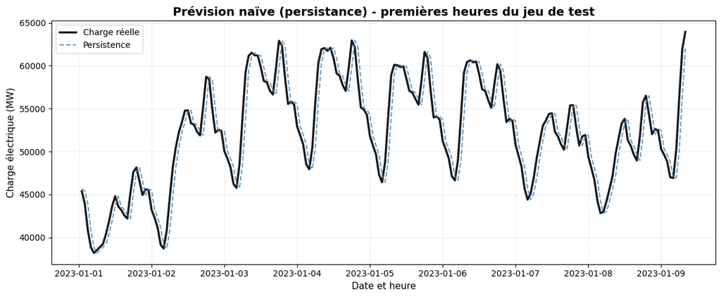

```python
fig, ax = plt.subplots(figsize=(12, 5))

ax.plot(y_true.index[:200], y_true.iloc[:200],
        label='Charge réelle', linewidth=2.5, color='black', alpha=0.9)
ax.plot(y_true.index[:200], y_pred_persistence.iloc[:200],
        label='Persistence', linestyle='--', linewidth=1.5, color='steelblue', alpha=0.8)

ax.set_title('Prévision naïve (persistance) - premières heures du jeu de test',
             fontsize=14, fontweight='bold')
ax.set_xlabel('Date et heure', fontsize=11)
ax.set_ylabel('Charge électrique (MW)', fontsize=11)
ax.legend(loc='best', fontsize=10)
ax.grid(alpha=0.3, linestyle='--')
plt.tight_layout()
plt.show()
```

Le modèle de persistance suit de près la charge observée et reproduit correctement les cycles journaliers. Cependant, il présente un retard systématique lors des variations rapides et ne permet pas d’anticiper les changements brusques. Cela souligne la nécessité de recourir à des modèles plus élaborés intégrant des variables explicatives.

### Modèle de régression linéaire avec variables explicatives

Un modèle de régression linéaire est ensuite mis en place afin d’intégrer explicitement les facteurs explicatifs identifiés lors de l’EDA, notamment la température et les variables calendaires.

Ce modèle constitue une première approche interprétable de la relation entre la charge électrique et ses principaux déterminants.

```python
features = ["temperature", "hour", "day_of_week", "is_weekend"]

X_train = train[features]
y_train = train["load_mw"]

X_test = test[features]
y_test = test["load_mw"]

from sklearn.linear_model import LinearRegression

reg = LinearRegression()
reg.fit(X_train, y_train)

y_pred_reg = reg.predict(X_test)

mae_reg = mean_absolute_error(y_test, y_pred_reg)
rmse_reg = np.sqrt(mean_squared_error(y_test, y_pred_reg))

mae_reg, rmse_reg
```

```
(5634.2999278377765, np.float64(6976.52794971721))
```

```python
results = {
    "Persistence": (mae_persist, rmse_persist),
    "Linear regression": (mae_reg, rmse_reg)
}

results
```

```
{'Persistence': (1585.3716455407102, np.float64(1973.849057129457)),
 'Linear regression': (5634.2999278377765, np.float64(6976.52794971721))}
```

Le modèle de régression linéaire présente des performances inférieures au modèle de persistance. Ce résultat met en évidence la forte dépendance temporelle de la charge électrique à l’échelle horaire.

Bien que la température et les variables calendaires expliquent le niveau moyen de la demande, elles ne suffisent pas à capturer la dynamique de court terme. Cela motive l’utilisation de modèles de séries temporelles intégrant des composantes autorégressives.

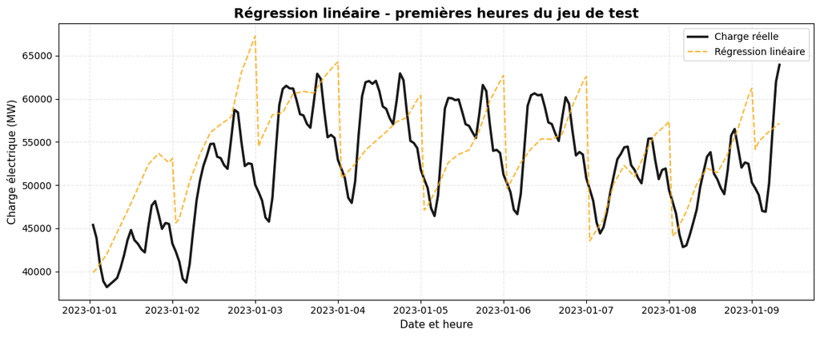

```python
fig, ax = plt.subplots(figsize=(12, 5))

ax.plot(y_true.index[:200], y_true.iloc[:200],
        label='Charge réelle', linewidth=2.5, color='black', alpha=0.9)
ax.plot(y_true.index[:200], y_pred_reg[:200],
        label='Régression linéaire', linestyle='--', linewidth=1.5, color='orange', alpha=0.8)

ax.set_title('Régression linéaire - premières heures du jeu de test',
             fontsize=14, fontweight='bold')
ax.set_xlabel('Date et heure', fontsize=11)
ax.set_ylabel('Charge électrique (MW)', fontsize=11)
ax.legend(loc='best', fontsize=10)
ax.grid(alpha=0.3, linestyle='--')
plt.tight_layout()
plt.show()
```

Le modèle de régression linéaire produit des prévisions excessivement lissées et ne parvient pas à capturer les variations horaires rapides. Bien qu’il explique correctement le niveau moyen de la charge, il reproduit mal la dynamique intrajournalière.

Cette observation visuelle confirme les performances inférieures mesurées précédemment.

```python
coeffs = pd.Series(reg.coef_, index=features)
coeffs
```

```
temperature   -1117.590246
hour            575.220127
day_of_week      14.033963
is_weekend    -5905.672825
dtype: float64
```

Les coefficients de la régression confirment l’impact négatif marqué de la température sur la demande électrique. Une augmentation de 1 °C est associée à une baisse moyenne d’environ 1,1 GW de la charge.

L’effet week-end est également très significatif, avec une demande inférieure d’environ 6 GW. Cependant, la spécification linéaire des effets horaires limite la capacité du modèle à capturer la dynamique intrajournalière.

### Modèle SARIMAX

Un modèle SARIMAX est ensuite envisagé afin de capturer simultanément les dépendances temporelles, la saisonnalité journalière et l’effet exogène de la température.

Malgré plusieurs spécifications testées, le modèle SARIMAX s’est révélé instable sur notre série, avec des problèmes de convergence et un biais important sur le niveau moyen de la charge, conduisant à des prévisions non physiquement plausibles.

```python
# Préparation robuste pour statsmodels (SARIMAX)
df_smx = df_final.copy()

# 1) index datetime propre
df_smx = df_smx.sort_index()
df_smx = df_smx[~df_smx.index.duplicated(keep="first")]

# 2) enlever timezone si présent (statsmodels préfère naïf)
if getattr(df_smx.index, "tz", None) is not None:
    df_smx.index = df_smx.index.tz_convert("Europe/Paris").tz_localize(None)

# 3) forcer une grille horaire complète + freq reconnue
full_idx = pd.date_range(df_smx.index.min(), df_smx.index.max(), freq="h")
df_smx = df_smx.reindex(full_idx)

# 4) gérer les trous
df_smx["load_mw"] = df_smx["load_mw"].interpolate(method='linear', limit=24)
df_smx["temperature"] = df_smx["temperature"].interpolate(method='linear', limit=24)

df_smx = df_smx.dropna(subset=["load_mw", "temperature"])

df_smx.index.freq = 'h'
```

```python
train = df_smx.loc[: "2022-12-31 23:00:00"].copy()
test  = df_smx.loc["2023-01-01 00:00:00" :].copy()

train.index.freq = 'h'
test.index.freq = 'h'


y_train = train["load_mw"]
y_test  = test["load_mw"]

exog_train = train[["temperature"]]
exog_test  = test[["temperature"]]
```

```python
from statsmodels.tsa.statespace.sarimax import SARIMAX

model = SARIMAX(
    y_train,
    exog=exog_train,
    order=(1,0,1),
    seasonal_order=(1,0,1,24),
    enforce_stationarity=False,
    enforce_invertibility=False
)
res = model.fit(disp=False)

pred = res.get_forecast(steps=len(y_test), exog=exog_test).predicted_mean
pred.index = y_test.index
```

```python
mae_sarimax = mean_absolute_error(y_test, pred)
rmse_sarimax = np.sqrt(mean_squared_error(y_test, pred))

print("SARIMAX MAE :", mae_sarimax)
print("SARIMAX RMSE:", rmse_sarimax)
```

```
SARIMAX MAE : 21446.296129469996
SARIMAX RMSE: 26903.41914352785
```

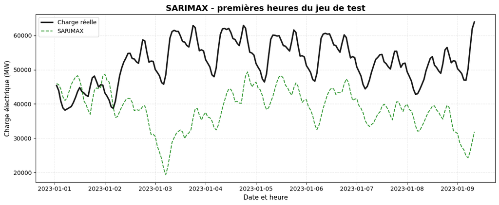

```python
fig, ax = plt.subplots(figsize=(12, 5))

ax.plot(y_true.index[:200], y_true.iloc[:200],
        label='Charge réelle', linewidth=2.5, color='black', alpha=0.9)
ax.plot(y_true.index[:200], pred.iloc[:200],
        label='SARIMAX', linestyle='--', linewidth=1.5, color='green', alpha=0.8)

ax.set_title('SARIMAX - premières heures du jeu de test',
             fontsize=14, fontweight='bold')
ax.set_xlabel('Date et heure', fontsize=11)
ax.set_ylabel('Charge électrique (MW)', fontsize=11)
ax.legend(loc='best', fontsize=10)
ax.grid(alpha=0.3, linestyle='--')
plt.tight_layout()
plt.show()
```

Dans ce contexte, le modèle de persistance demeure l’approche la plus fiable pour la prévision de court terme de la charge électrique.

Nous avons donc privilégié un modèle de séries temporelles plus robuste et mieux adapté à une forte saisonnalité intrajournalière : l’Exponential Smoothing (Holt-Winters/ETS) avec une saisonnalité de période 24. Ce modèle capture directement les motifs répétitifs journaliers observés lors de l’EDA, tout en restant stable et facile à estimer, ce qui en fait une alternative pertinente pour la prévision de court terme.

### Modèle ETS (Holt-Winters)

Compte tenu des limitations observées avec le SARIMAX, un modèle de séries temporelles ETS (Holt-Winters) est retenu.

Ce modèle, basé sur une décomposition additive avec une saisonnalité journalière de période 24, permet de capturer directement les motifs répétitifs observés lors de l’EDA tout en garantissant des prévisions stables.

```python
from statsmodels.tsa.holtwinters import ExponentialSmoothing

y_train_ets = y_train.copy()
y_test_ets  = y_test.copy()

y_train_ets.index.freq = 'h'
y_test_ets.index.freq = 'h'


ets = ExponentialSmoothing(
    y_train_ets,
    trend="add",
    seasonal="add",
    seasonal_periods=24,
    initialization_method="estimated"
).fit(optimized=True)

y_pred_ets = ets.forecast(steps=len(y_test_ets))
y_pred_ets.index = y_test_ets.index

mae_ets = mean_absolute_error(y_test_ets, y_pred_ets)
rmse_ets = np.sqrt(mean_squared_error(y_test_ets, y_pred_ets))
(mae_ets, rmse_ets)
```

```
(8202.904845247731, np.float64(11322.611758222742))
```

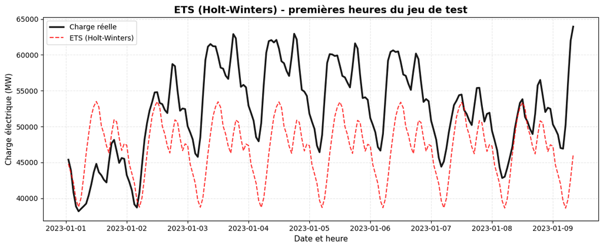

```python
fig, ax = plt.subplots(figsize=(12, 5))

ax.plot(y_true.index[:200], y_true.iloc[:200],
        label='Charge réelle', linewidth=2.5, color='black', alpha=0.9)
ax.plot(y_true.index[:200], y_pred_ets[:200],
        label='ETS (Holt-Winters)', linestyle='--', linewidth=1.5, color='red', alpha=0.8)

ax.set_title('ETS (Holt-Winters) - premières heures du jeu de test',
             fontsize=14, fontweight='bold')
ax.set_xlabel('Date et heure', fontsize=11)
ax.set_ylabel('Charge électrique (MW)', fontsize=11)
ax.legend(loc='best', fontsize=10)
ax.grid(alpha=0.3, linestyle='--')
plt.tight_layout()
plt.show()
```

Le modèle ETS (Holt-Winters) reproduit correctement la structure intrajournalière de la charge électrique, en capturant efficacement les cycles journaliers mis en évidence lors de l’analyse exploratoire.

### Tableau recaptitulatif

```python
# Note : installer tabulate si nécessaire : pip install tabulate

results_df = pd.DataFrame({
    'Modèle': ['Persistence', 'Régression linéaire', 'SARIMAX', 'ETS (Holt-Winters)'],
    'MAE (MW)': [mae_persist, mae_reg, mae_sarimax, mae_ets],
    'RMSE (MW)': [rmse_persist, rmse_reg, rmse_sarimax, rmse_ets]
}).sort_values('MAE (MW)')

print("\n TABLEAU COMPARATIF DES MODÈLES ")
print(results_df.to_string(index=False))
```

```
 TABLEAU COMPARATIF DES MODÈLES
             Modèle     MAE (MW)    RMSE (MW)
        Persistence  1585.371646  1973.849057
Régression linéaire  5634.299928  6976.527950
 ETS (Holt-Winters)  8202.904845 11322.611758
            SARIMAX 21446.296129 26903.419144
```

Le modèle de persistance est clairement le plus performant (MAE ≈ 1585 MW), ce qui est attendu pour la prévision à très court terme en raison de la forte autocorrélation horaire de la série.

La régression linéaire, malgré l'intégration de variables explicatives pertinentes, ne parvient pas à capturer la dynamique temporelle (MAE 3,5× supérieur). Le modèle ETS affiche un MAE plus élevé (≈ 8203 MW) car il effectue une prévision statique sur toute l'année 2023, sans mise à jour continue comme la persistance. Le SARIMAX confirme son instabilité avec un MAE dépassant 21 000 MW.

### Graphique comparatif

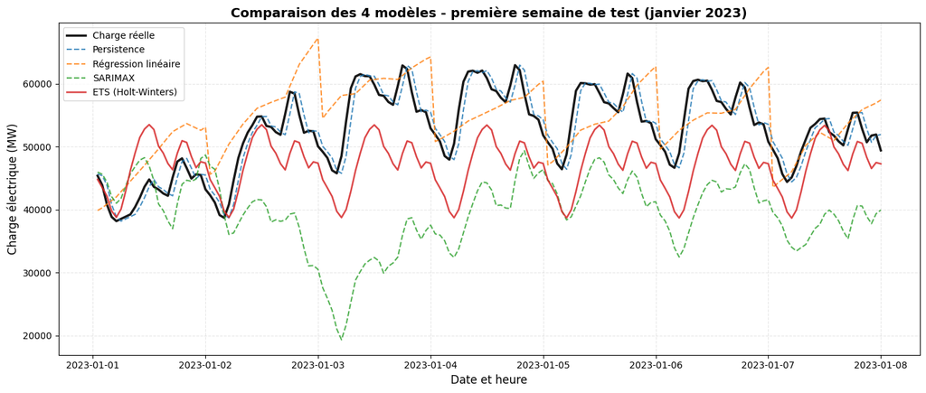

```python
week_start = 0
week_end = 168

fig, ax = plt.subplots(figsize=(14, 6))

# Valeurs réelles
ax.plot(y_true.index[week_start:week_end],
        y_true.iloc[week_start:week_end],
        label='Charge réelle', linewidth=2.5, color='black', alpha=0.9)

# Persistence
ax.plot(y_true.index[week_start:week_end],
        y_pred_persistence.iloc[week_start:week_end],
        label='Persistence', linestyle='--', alpha=0.8, linewidth=1.5)

# Régression linéaire
ax.plot(y_true.index[week_start:week_end],
        y_pred_reg[week_start:week_end],
        label='Régression linéaire', linestyle='--', alpha=0.8, linewidth=1.5)

# SARIMAX
ax.plot(y_true.index[week_start:week_end],
        pred.iloc[week_start:week_end],
        label='SARIMAX', linestyle='--', alpha=0.8, linewidth=1.5)

# ETS
ax.plot(y_true.index[week_start:week_end],
        y_pred_ets.iloc[week_start:week_end],
        label='ETS (Holt-Winters)', linestyle='-', alpha=0.85, linewidth=1.8)

ax.set_title('Comparaison des 4 modèles - première semaine de test (janvier 2023)',
             fontsize=14, fontweight='bold')
ax.set_xlabel('Date et heure', fontsize=12)
ax.set_ylabel('Charge électrique (MW)', fontsize=12)
ax.legend(loc='best', fontsize=10)
ax.grid(alpha=0.3, linestyle='--')
plt.tight_layout()
plt.show()
```

La comparaison visuelle sur la première semaine de test illustre clairement la supériorité du modèle de persistance (bleu pointillé), qui suit de très près la charge réelle (noir). La régression linéaire (orange) produit une courbe excessivement lissée qui ne capture pas les variations horaires. Le SARIMAX (vert) génère des prévisions aberrantes avec une sous-estimation massive et même des effondrements vers 20 000 MW le 3 janvier. Le modèle ETS (rouge), bien que moins précis que la persistance, maintient une structure cohérente avec une saisonnalité journalière marquée, mais décalée en niveau.

### Analyse des erreurs (ETS)

```
Statistiques sur les erreurs (ETS):
  Erreur moyenne : 6453.51 MW
  Écart-type : 9303.96 MW
  Erreur max (sur-estimation) : 34989.14 MW
  Erreur min (sous-estimation) : -12184.49 MW
```

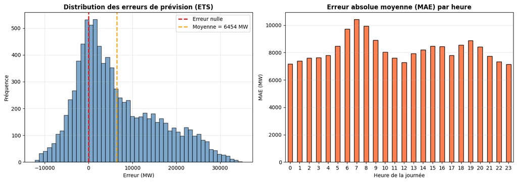

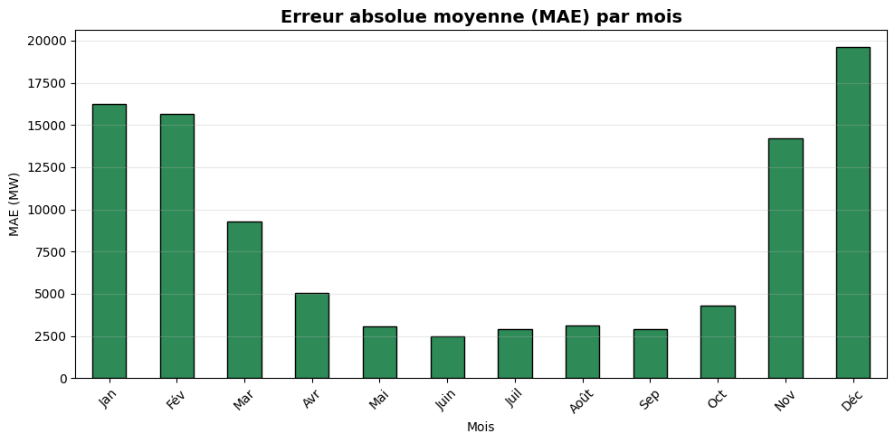

```python
errors = y_test_ets - y_pred_ets

print(f"Statistiques sur les erreurs (ETS):")
print(f"  Erreur moyenne : {errors.mean():.2f} MW")
print(f"  Écart-type : {errors.std():.2f} MW")
print(f"  Erreur max (sur-estimation) : {errors.max():.2f} MW")
print(f"  Erreur min (sous-estimation) : {errors.min():.2f} MW")

# GRAPHIQUE 1 : Distribution + Erreur par heure
fig, axes = plt.subplots(1, 2, figsize=(14, 5))

axes[0].hist(errors, bins=50, edgecolor='black', alpha=0.7, color='steelblue')
axes[0].axvline(0, color='red', linestyle='--', linewidth=2, label='Erreur nulle')
axes[0].axvline(errors.mean(), color='orange', linestyle='--', linewidth=2,
                label=f'Moyenne = {errors.mean():.0f} MW')
axes[0].set_title('Distribution des erreurs de prévision (ETS)', fontweight='bold')
axes[0].set_xlabel('Erreur (MW)')
axes[0].set_ylabel('Fréquence')
axes[0].legend()
axes[0].grid(alpha=0.3)

error_by_hour = pd.DataFrame({
    'hour': y_test_ets.index.hour,
    'abs_error': errors.abs()
}).groupby('hour')['abs_error'].mean()

error_by_hour.plot(kind='bar', ax=axes[1], color='coral', edgecolor='black')
axes[1].set_title('Erreur absolue moyenne (MAE) par heure', fontweight='bold')
axes[1].set_xlabel('Heure de la journée')
axes[1].set_ylabel('MAE (MW)')
axes[1].set_xticklabels(range(24), rotation=0)
axes[1].grid(alpha=0.3, axis='y')

plt.tight_layout()
plt.show()

# GRAPHIQUE 2 : Erreur par mois
error_by_month = pd.DataFrame({
    'month': y_test_ets.index.month,
    'abs_error': errors.abs()
}).groupby('month')['abs_error'].mean()

fig, ax = plt.subplots(figsize=(10, 5))
error_by_month.plot(kind='bar', ax=ax, color='seagreen', edgecolor='black')
ax.set_title('Erreur absolue moyenne (MAE) par mois', fontsize=14, fontweight='bold')
ax.set_xlabel('Mois')
ax.set_ylabel('MAE (MW)')
ax.set_xticklabels(['Jan', 'Fév', 'Mar', 'Avr', 'Mai', 'Juin',
                    'Juil', 'Août', 'Sep', 'Oct', 'Nov', 'Déc'], rotation=45)
ax.grid(alpha=0.3, axis='y')
plt.tight_layout()
plt.show()
```

L'analyse des erreurs révèle un biais systématique de sous-estimation : l'erreur moyenne est de +6454 MW, ce qui signifie que le modèle ETS prédit en moyenne une charge inférieure à la réalité. Ce biais explique en grande partie les performances modestes observées dans le tableau comparatif.

L'erreur par mois révèle une forte saisonnalité : les erreurs sont maximales en hiver (janvier, février, décembre : 15 000-20 000 MW) et minimales en été (mai-septembre : 2500-4000 MW). Cela s'explique par la plus forte variabilité de la charge en hiver (chauffage électrique sensible aux températures) et par le fait que le modèle ETS, entraîné sur 2020-2022, a du mal à généraliser sur toute l'année 2023 sans mise à jour.

Ces observations confirment que le modèle ETS, bien que structurellement cohérent, souffre d'un manque d'adaptabilité en prévision statique à long terme.

## 4. Implications pratiques pour les opérateurs système

Les résultats de cette étude ont des conséquences directes sur la gestion opérationnelle du réseau électrique :

Dimensionnement des réserves : Le modèle de persistance, avec un RMSE de 1974 MW, suggère qu'une marge de sécurité d'environ 4000 MW (2×RMSE) permettrait de couvrir 95% des erreurs de prévision à l'horizon 1 heure. Pour des horizons plus longs nécessitant des modèles comme ETS, les marges devront être significativement accrues, notamment en hiver (erreurs 5-6× supérieures à l'été).

Heures critiques : Les rampes de charge aux heures de pointe (6h-8h, 18h-20h) concentrent les erreurs maximales. Une vigilance particulière et des réserves additionnelles sont requises durant ces transitions.

## Conclusion générale

Ce projet avait pour objectif d'analyser et de modéliser la charge électrique horaire en France à partir de données de consommation (RTE) et de température (Météo-France) sur la période 2020–2023.

### Synthèse des résultats

L'analyse exploratoire a mis en évidence des saisonnalités marquées à plusieurs échelles temporelles (journalière, hebdomadaire, annuelle) ainsi qu'une forte dépendance de la charge électrique aux conditions climatiques, en particulier aux températures basses en hiver. Ces observations ont guidé le choix des modèles de prévision testés.

L'analyse détaillée des erreurs du modèle ETS révèle un biais systématique de sous-estimation (≈ 6500 MW en moyenne), des erreurs maximales aux heures de pointe (6h-8h, 18h-20h) et une forte variabilité saisonnière (erreurs 5-6× supérieures en hiver qu'en été).

### Implications opérationnelles

Ces résultats ont des conséquences directes pour la gestion du système électrique. Le RMSE de la persistance (≈ 1974 MW) suggère qu'une marge de sécurité d'environ 4000 MW permettrait de couvrir 95% des erreurs de prévision à l'horizon 1 heure. Les rampes de charge aux heures de pointe et la variabilité hivernale nécessitent une attention particulière et des réserves accrues durant ces périodes critiques. L'amélioration de la qualité des prévisions représente un enjeu économique significatif pour l'optimisation des coûts de réserves et de sollicitation des moyens de production.

### Limites et perspectives

Les perspectives d'amélioration incluent l'intégration de modèles non linéaires plus avancés (réseaux de neurones LSTM, modèles hybrides), l'introduction de variables exogènes supplémentaires (jours fériés, données socio-économiques, nébulosité), et le développement de prévisions probabilistes permettant de quantifier l'incertitude pour optimiser le dimensionnement des réserves en fonction du risque acceptable.

Ce travail démontre que la prévision de charge électrique à court terme reste un exercice délicat nécessitant de combiner analyse statistique rigoureuse et connaissance approfondie du domaine d'application.